# Overnight CO2 Aim3 Final

- Show All Code
- Hide All Code
- View Source

Author

Zheng Ren

Published

June 16, 2024

```r
univariate_mix_logistic = function(outcome, variable, mix_df){
  glm1 = glm(as.formula(paste0(outcome, " ~ ", variable)), data = mix_df, family = binomial(link = "logit"))
  model = glmer(as.formula(paste0(outcome, " ~ ", variable, " + (1 | subject)")), data = mix_df, family = binomial(link = "logit"), start = list(fixef=coef(glm1)), control = glmerControl(nAGQ0initStep=FALSE))
  result = model %>% tidy(conf.int = TRUE) %>% filter(term == variable) %>% dplyr::select(term, conf.low, estimate, conf.high, p.value) %>% mutate(outcome = outcome)
  return(result)
}

univariate_mix = function(outcome, variable, mix_df){
  model = lmerTest::lmer(as.formula(paste0(outcome, " ~ ", variable, " + (1 | subject)")), data = mix_df)
  result = model %>% tidy(conf.int = TRUE) %>% filter(term == variable) %>% dplyr::select(term, conf.low, estimate, conf.high, p.value) %>% mutate(outcome = outcome)
  return(result)
}
```

In this Aim, we want to determine if 1) PtCO2 **raw features** extracted directly from nocturnal continuous data streams and 2) **wavelet features** extracted from nocturnal data streams after applying discrete wavelet transform are associated with standard clinical measurements **FVC** and **MIP**.

# 1 Method

**Step 1: Mixed Effects Model**

We used **mixed-effects model** (for continuous dependent variables) and **mixed-effects logistic regression model** (for binary dependent variables) to determine if any PtCO2 raw features and wavelet features are significantly associated with standard measurements FVC, MIP and SpO2 (suggested by Jason). We employed **univariate models** to avoid multicollinearity issues.

$$\text{standard measurement} \sim x_{i} + (1 | subject)$$

**Note**

$x_{i}$ is taken from both the **raw PtCO2 feature sets (18)** and the **wavelet feature sets (205)**. We tried two forms of standard measurements here:

- **continuous variable**: fvc, mip, spo2
- **binary variable** (event): mip > -60, mean spo2 < 88% (the model failed for fvc < 50 due to a lack of events)

**Step 2: Hierarchical Clustering**

- night level

we employed the complete-linkage method with Euclidean distance to identify distinct clusters at the **night level**.

- visit level

we applied the majority vote method to summarize the night-level result to the **visit-level**.

- subject level

we applied the majority vote method to summarize the visit-level result to the **subject-level**.

**Step 3: Cox Regression Model with Time-dependent Covariates**

We employed Cox regression model with time-dependent covariates to quantify an effect size of a time-varying variable on the occurrence of the event of interest.

The quantity of interest from the model is a hazard ratio (HR). A HR < 1 indicates reduced hazard of the event of interest whereas a HR > 1 indicates an increased hazard of the event of interest.

$$h(t|Z(t)) = h_{0}(t)exp(\beta'x + \gamma'Xg(t))$$
$$Z(t) = [x_{1}, x_{2} ... x_{p}, X_{1}g(t), X_{2}g(t)...X_{q}g(t)]$$
where $\beta'$ and $\gamma'$ are coefficients of time-fixed and time-varying covariate respectively. $Z(t)$ represent the covariates ($x_{i}$ represents time-fixed variable whereas $X_{i}g(t)$ represents time-varying variable. $h(t)$ is the hazard ratio at which events occur. $h(t_{0})$ is the underlying baseline hazard.

**Note**

In our analysis, we used FVC < 50 and MIP > -60 as the events of interest (**time to first occurrence**), with PtCO2 raw features as time-varying covariates (**fitting one feature at a time**).

$$h(t|X_{1}g(t)) = h_{0}(t)exp(\beta'X_{1}g(t))$$
$h(t)$ is the hazard ratio at which MIP or FVC events first occurred. $h(t_{0})$ is the underlying baseline hazard. $X_{1}$ is the single time-varying variable from PtCO2 raw feature sets.

# 2 Result

## 2.1 Mixed Effect Model

```r
wave_features = colnames(features_df)[-c(1:2)]
wave_features = sapply(wave_features, function(x) gsub(" ", "_", x), USE.NAMES = FALSE)
colnames(features_df) = c(colnames(features_df)[1:2], wave_features)

# Mixed Model Data
mix_df = subject_summary %>% left_join(features_df, by = c("subject", "day")) %>% na.omit() %>% group_by(subject, visit) %>% summarise_if(is.numeric, mean, na.rm = TRUE) %>% ungroup()
mix_df= mix_df[,apply(mix_df, 2, function(col) { length(unique(col)) > 1 })]
wave_features = colnames(mix_df)[grepl("_level_", colnames(mix_df))]
wave_features = wave_features[which(!grepl("*_13$|*_12$|*_11$|*_10$", wave_features))]
mix_df[wave_features] = scale(mix_df[wave_features], center = TRUE, scale = TRUE)
mix_df$subject = as.factor(mix_df$subject)
mix_df = mix_df %>% mutate(fvc_50 = case_when(fvc < 50 ~ 1,
                                              fvc >= 50 ~ 0),
                           mip_60 = case_when(mip > -60 ~ 1,
                                              mip <= -60 ~ 0),
                           spo2_88 = case_when(event_spo2 > 0 ~ 1,
                                               event_spo2 == 0 ~ 0))
```

**Raw Features**

- Continuous Outcome

It appears that the **mean and median level of PtCO2** are **negatively** associated with **SpO2**. Additionally, the **range of PtCO2** and the **standard deviations** of both the PCO2 and the PCO2 changes from the baseline have a significant association with FVC.

```r
# Raw Feature Significance
raw_features = colnames(mix_df)[c(3:4, 10:15, 17:22, 31:34)]
fvc_con = lapply(raw_features, function(x) univariate_mix("fvc", x, mix_df)) %>% bind_rows() %>% arrange(p.value)
mip_con = lapply(raw_features, function(x) univariate_mix("mip", x, mix_df)) %>% bind_rows() %>% arrange(p.value)
spo2_con = lapply(raw_features, function(x) univariate_mix("mean_SpO2", x, mix_df)) %>% bind_rows() %>% arrange(p.value)
con_result = rbind(fvc_con, mip_con, spo2_con) %>% arrange(p.value) %>% filter(p.value <= 0.1) %>% mutate(conf.low = sprintf("%.3f", conf.low), estimate = sprintf("%.3f", estimate), conf.high = sprintf("%.3f", conf.high), p.value = sprintf("%.3f", p.value))
kable(con_result, align = "c") %>% kable_styling(bootstrap_options = "striped") %>% row_spec(which(as.numeric(con_result$p.value) <= 0.05), bold = F, color = "black", background = "lightyellow") %>%
  kable_classic(html_font = "Cambria") %>%
  column_spec(3, color = ifelse(as.numeric(con_result$estimate) < 0, "green", "red"))
```

| term | conf.low | estimate | conf.high | p.value | outcome |
| --- | --- | --- | --- | --- | --- |
| mean_PCO2 | -0.210 | -0.120 | -0.029 | 0.012 | mean_SpO2 |
| median_PCO2 | -0.207 | -0.117 | -0.027 | 0.013 | mean_SpO2 |
| PCO2_range | 0.214 | 0.994 | 1.774 | 0.014 | fvc |
| sd_delta_pct | 0.297 | 2.242 | 4.187 | 0.025 | fvc |
| sd_PCO2 | 0.697 | 5.593 | 10.490 | 0.027 | fvc |
| event_45.10 | -0.435 | -0.214 | 0.007 | 0.057 | mean_SpO2 |
| event_45 | -0.211 | -0.100 | 0.011 | 0.075 | mean_SpO2 |

- Binary Outcome

It appears that the **standard deviation of PtCO2 changes from the spot CO2 baseline** has a significant association with the occurrence of **absolute MIP going below 60**.

```r
# Raw Feature Significance
#fvc_bi = lapply(raw_features, function(x) #univariate_mix_logistic("fvc_50", x, mix_df)) %>% bind_rows() %>% arrange(p.value)
mip_bi = lapply(raw_features, function(x) univariate_mix_logistic("mip_60", x, mix_df)) %>% bind_rows() %>% arrange(p.value)
spo2_bi = lapply(raw_features, function(x) univariate_mix_logistic("spo2_88", x, mix_df)) %>% bind_rows() %>% arrange(p.value)
bi_result = rbind(mip_bi, spo2_bi) %>% arrange(p.value) %>% filter(p.value <= 0.1) %>% mutate(conf.low = sprintf("%.3f", conf.low), estimate = sprintf("%.3f", estimate), conf.high = sprintf("%.3f", conf.high), p.value = sprintf("%.3f", p.value))
kable(bi_result, align = "c") %>% kable_styling(bootstrap_options = "striped") %>% row_spec(which(as.numeric(bi_result$p.value) <= 0.05), bold = F, color = "black", background = "lightyellow") %>%
  kable_classic(html_font = "Cambria") %>%
  column_spec(3, color = ifelse(as.numeric(bi_result$estimate) < 0, "green", "red"))
```

| term | conf.low | estimate | conf.high | p.value | outcome |
| --- | --- | --- | --- | --- | --- |
| sd_delta_pct | -0.350 | -0.346 | -0.343 | 0.000 | mip_60 |

**Wavelet Features**

This section shows some potential significant wavelet features. Further validating the results requires a larger sample size.

- Continuous Outcome

```r
# Raw Feature Significance
fvc_con = lapply(wave_features, function(x) univariate_mix("fvc", x, mix_df)) %>% bind_rows() %>% arrange(p.value)
mip_con = lapply(wave_features, function(x) univariate_mix("mip", x, mix_df)) %>% bind_rows() %>% arrange(p.value)
spo2_con = lapply(wave_features, function(x) univariate_mix("mean_SpO2", x, mix_df)) %>% bind_rows() %>% arrange(p.value)
con_result = rbind(fvc_con, mip_con, spo2_con) %>% arrange(p.value) %>% filter(p.value <= 0.05) %>% mutate(conf.low = sprintf("%.3f", conf.low), estimate = sprintf("%.3f", estimate), conf.high = sprintf("%.3f", conf.high), p.value = sprintf("%.3f", p.value))
kable(con_result, align = "c") %>% kable_styling(bootstrap_options = "striped") %>% row_spec(which(as.numeric(con_result$p.value) <= 0.05), bold = F, color = "black", background = "lightyellow") %>%
  kable_classic(html_font = "Cambria") %>%
  column_spec(3, color = ifelse(as.numeric(con_result$estimate) < 0, "green", "red"))
```

| term | conf.low | estimate | conf.high | p.value | outcome |
| --- | --- | --- | --- | --- | --- |
| statistic_features.n75_d_level_5 | 6.416 | 10.314 | 14.211 | 0.000 | fvc |
| statistic_features.n95_d_level_4 | 4.993 | 9.025 | 13.057 | 0.000 | fvc |
| statistic_features.mean_d_level_5 | 3.819 | 7.774 | 11.728 | 0.000 | fvc |
| statistic_features.n95_d_level_5 | 2.992 | 7.076 | 11.159 | 0.001 | fvc |
| statistic_features.n75_d_level_4 | 2.495 | 6.711 | 10.927 | 0.003 | fvc |
| statistic_features.std_d_level_4 | 2.385 | 6.413 | 10.442 | 0.003 | fvc |
| statistic_features.std_d_level_5 | 2.399 | 6.710 | 11.020 | 0.003 | fvc |
| statistic_features.n5_d_level_5 | -12.067 | -7.300 | -2.533 | 0.004 | fvc |
| statistic_features.n95_d_level_2 | 2.062 | 6.621 | 11.180 | 0.006 | fvc |
| statistic_features.std_d_level_7 | 2.229 | 7.371 | 12.512 | 0.006 | fvc |
| statistic_features.rms_d_level_4 | 1.676 | 5.685 | 9.693 | 0.007 | fvc |
| statistic_features.rms_d_level_7 | 1.832 | 6.525 | 11.218 | 0.008 | fvc |
| statistic_features.var_d_level_7 | 1.825 | 6.523 | 11.221 | 0.008 | fvc |
| statistic_features.n75_d_level_2 | 1.769 | 6.444 | 11.119 | 0.008 | fvc |
| statistic_features.var_d_level_4 | 1.554 | 5.582 | 9.611 | 0.009 | fvc |
| statistic_features.n95_d_level_6 | 1.686 | 6.519 | 11.353 | 0.010 | fvc |
| entropy_d_level_8 | -9.827 | -5.650 | -1.474 | 0.010 | fvc |
| statistic_features.rms_d_level_5 | 1.348 | 5.488 | 9.628 | 0.011 | fvc |
| statistic_features.var_d_level_5 | 1.312 | 5.456 | 9.601 | 0.012 | fvc |
| statistic_features.std_d_level_6 | 1.335 | 6.247 | 11.160 | 0.014 | fvc |
| entropy_d_level_2 | -9.998 | -5.590 | -1.182 | 0.015 | fvc |
| statistic_features.median_d_level_5 | 0.102 | 0.490 | 0.877 | 0.015 | mean_SpO2 |
| statistic_features.n5_d_level_4 | -9.371 | -5.202 | -1.032 | 0.016 | fvc |
| statistic_features.rms_d_level_6 | 0.950 | 5.299 | 9.648 | 0.019 | fvc |
| statistic_features.var_d_level_6 | 0.927 | 5.281 | 9.636 | 0.019 | fvc |
| statistic_features.n95_d_level_7 | 1.190 | 7.143 | 13.096 | 0.020 | fvc |
| statistic_features.std_d_level_8 | 1.058 | 6.722 | 12.386 | 0.022 | fvc |
| statistic_features.std_d_level_2 | 0.788 | 5.145 | 9.503 | 0.022 | fvc |
| statistic_features.std_c_level_9 | 0.734 | 5.202 | 9.670 | 0.024 | fvc |
| statistic_features.std_c_level_6 | 0.660 | 5.033 | 9.407 | 0.026 | fvc |
| statistic_features.std_c_level_8 | 0.669 | 5.115 | 9.560 | 0.026 | fvc |
| statistic_features.std_c_level_7 | 0.601 | 5.024 | 9.447 | 0.027 | fvc |
| statistic_features.rms_d_level_2 | 0.535 | 4.713 | 8.891 | 0.029 | fvc |
| zero_cross_d_level_4 | 0.041 | 0.390 | 0.739 | 0.030 | mean_SpO2 |
| statistic_features.var_d_level_2 | 0.382 | 4.592 | 8.801 | 0.034 | fvc |
| statistic_features.n75_d_level_6 | 0.222 | 5.355 | 10.488 | 0.041 | fvc |
| statistic_features.var_d_level_8 | 0.224 | 5.828 | 11.432 | 0.042 | fvc |
| statistic_features.rms_d_level_8 | 0.216 | 5.822 | 11.429 | 0.042 | fvc |
| statistic_features.n5_d_level_7 | -10.921 | -5.534 | -0.147 | 0.044 | fvc |
| zero_cross_d_level_2 | 0.009 | 0.452 | 0.896 | 0.046 | mean_SpO2 |
| entropy_d_level_9 | -9.323 | -4.705 | -0.088 | 0.046 | fvc |
| zero_cross_d_level_6 | -0.891 | -0.449 | -0.006 | 0.047 | mean_SpO2 |
| statistic_features.var_c_level_6 | 0.058 | 4.374 | 8.690 | 0.047 | fvc |
| statistic_features.var_c_level_9 | 0.005 | 4.369 | 8.734 | 0.050 | fvc |
| statistic_features.std_c_level_5 | 0.000 | 4.466 | 8.932 | 0.050 | fvc |

- Binary Outcome

```r
# Raw Feature Significance
#fvc_bi = lapply(raw_features, function(x) #univariate_mix_logistic("fvc_50", x, mix_df)) %>% bind_rows() %>% arrange(p.value)
mip_bi = lapply(wave_features, function(x) univariate_mix_logistic("mip_60", x, mix_df)) %>% bind_rows() %>% arrange(p.value)
spo2_bi = lapply(wave_features, function(x) univariate_mix_logistic("spo2_88", x, mix_df)) %>% bind_rows() %>% arrange(p.value)
bi_result = rbind(mip_bi, spo2_bi) %>% arrange(p.value) %>% filter(p.value <= 0.05) %>% mutate(conf.low = sprintf("%.3f", conf.low), estimate = sprintf("%.3f", estimate), conf.high = sprintf("%.3f", conf.high), p.value = sprintf("%.3f", p.value))
kable(bi_result, align = "c") %>% kable_styling(bootstrap_options = "striped") %>% row_spec(which(as.numeric(bi_result$p.value) <= 0.05), bold = F, color = "black", background = "lightyellow") %>%
  kable_classic(html_font = "Cambria") %>%
  column_spec(3, color = ifelse(as.numeric(bi_result$estimate) < 0, "green", "red"))
```

| term | conf.low | estimate | conf.high | p.value | outcome |
| --- | --- | --- | --- | --- | --- |
| entropy_c_level_3 | -0.959 | -0.956 | -0.953 | 0.000 | mip_60 |
| entropy_c_level_4 | -0.973 | -0.970 | -0.967 | 0.000 | mip_60 |
| statistic_features.n5_d_level_3 | 0.961 | 0.964 | 0.967 | 0.000 | mip_60 |
| statistic_features.n25_d_level_4 | 0.688 | 0.691 | 0.695 | 0.000 | mip_60 |
| statistic_features.mean_d_level_2 | 2.679 | 2.684 | 2.690 | 0.000 | mip_60 |
| statistic_features.std_c_level_8 | -0.732 | -0.729 | -0.726 | 0.000 | mip_60 |
| statistic_features.rms_d_level_2 | -0.678 | -0.675 | -0.672 | 0.000 | mip_60 |
| zero_cross_d_level_7 | 1.196 | 1.199 | 1.202 | 0.000 | mip_60 |
| zero_cross_d_level_8 | 1.171 | 1.174 | 1.177 | 0.000 | mip_60 |
| mean_cross_c_level_5 | 0.891 | 0.894 | 0.898 | 0.000 | mip_60 |
| statistic_features.n5_d_level_1 | 1.411 | 1.422 | 1.434 | 0.000 | spo2_88 |
| statistic_features.n75_d_level_5 | 1.158 | 1.164 | 1.170 | 0.000 | spo2_88 |
| statistic_features.median_d_level_5 | -0.277 | -0.270 | -0.263 | 0.000 | spo2_88 |
| statistic_features.mean_d_level_2 | 2.293 | 2.304 | 2.315 | 0.000 | spo2_88 |
| statistic_features.mean_d_level_8 | 15.278 | 15.287 | 15.295 | 0.000 | spo2_88 |
| statistic_features.var_d_level_3 | 0.265 | 0.272 | 0.278 | 0.000 | spo2_88 |
| statistic_features.var_d_level_6 | 2.553 | 2.559 | 2.564 | 0.000 | spo2_88 |
| statistic_features.rms_d_level_1 | -10.431 | -10.421 | -10.411 | 0.000 | spo2_88 |
| statistic_features.rms_d_level_6 | 2.564 | 2.569 | 2.575 | 0.000 | spo2_88 |
| zero_cross_d_level_9 | -0.165 | -0.158 | -0.152 | 0.000 | spo2_88 |
| mean_cross_c_level_6 | 48.613 | 48.616 | 48.619 | 0.000 | spo2_88 |
| mean_cross_d_level_9 | -0.151 | -0.145 | -0.138 | 0.000 | spo2_88 |

## 2.2 Hierarchical Clustering

We found **MIP** levels significantly differ between the **visit-level** clusters and the **subject-level** clusters.

**Night-level**

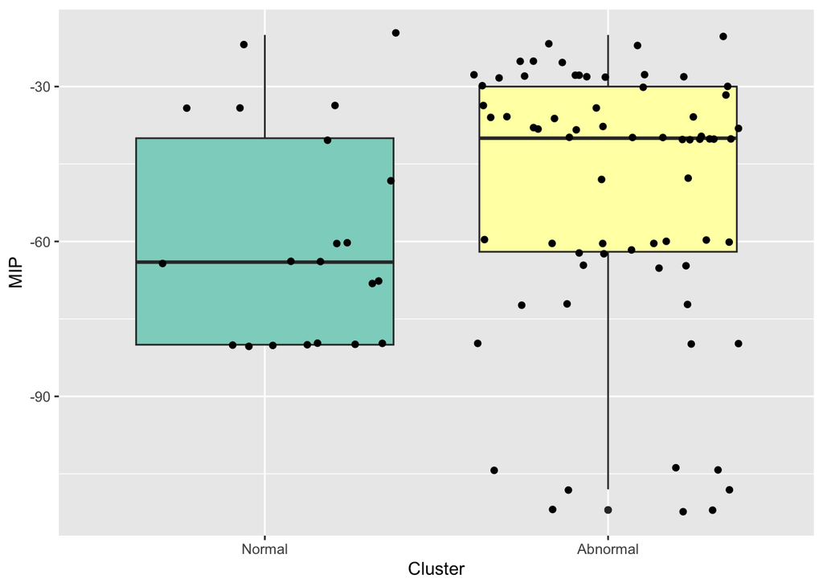

Figure 1: MIP Distribution Between Clusters (Night-level)

```r
k_means_df = subject_summary %>% left_join(features_df, by = c("subject", "day")) %>% na.omit()
mat = as.matrix(k_means_df[wave_features])
hclust.out = hclust(dist(mat))
k_means_df$cluster = cutree(hclust.out, k = 4)
k_means_df$cluster_night = sapply(k_means_df$cluster, function(x){case_when(x == 1 ~ 1, x == 2 ~ 1, x == 3 ~ 1, x == 4 ~ 0)}, USE.NAMES = FALSE)

ggplot(k_means_df, aes(x = as.factor(cluster_night), y = mip, fill = as.factor(cluster_night))) +
  geom_boxplot() +
  geom_jitter() +
  scale_x_discrete(labels = c("Normal", "Abnormal")) +
  scale_fill_brewer(palette = "Set3") +
  labs(x = "Cluster", y = "MIP", fill = "Cluster") +
  theme(legend.position = "none")

n_test = t.test(k_means_df$mip[which(k_means_df$cluster_night == 1)], k_means_df$mip[which(k_means_df$cluster_night == 0)], alternative = "two.sided")
```

- The Welch Two Sample t-test resulted in a p-value of 0.16, suggesting that there is no significant difference between the two groups.

**Visit-level**

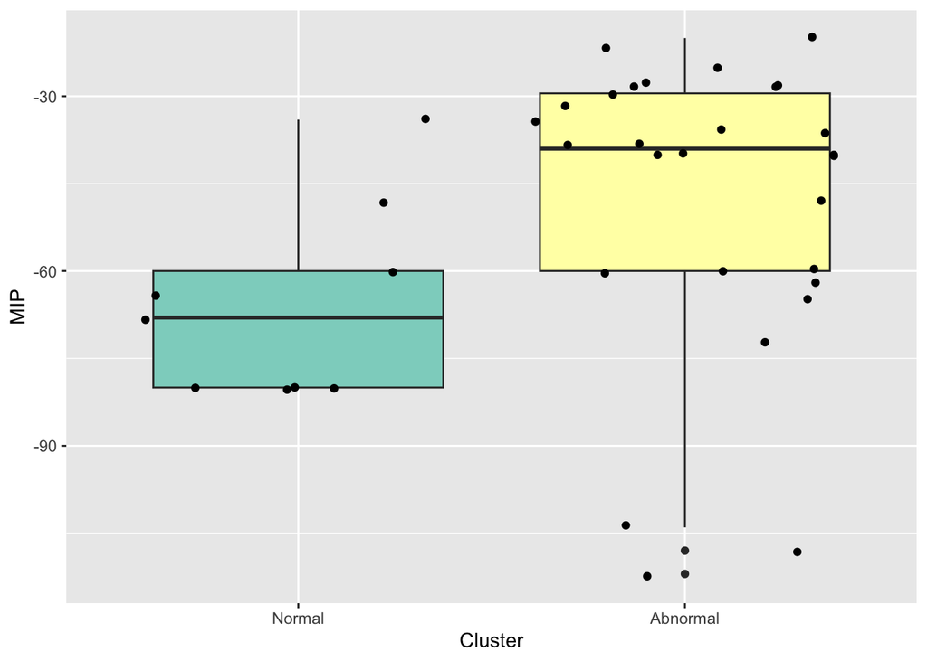

Figure 2: MIP Distribution Between Clusters (Visit-level)

```r
visit_cluster = k_means_df %>% dplyr::select(subject, year, visit, day, cluster_night) %>% group_by(subject, year, visit) %>% summarize(cluster_visit = mean(cluster_night)) %>% ungroup()
visit_cluster$cluster_visit = sapply(visit_cluster$cluster_visit, function(x) case_when(x>=0.5~1,
                      .default = 0), USE.NAMES = FALSE)
visit_cluster = visit_cluster %>% left_join(k_means_df %>% dplyr::select(subject, year, visit, mip, fvc), by = c("subject", "year", "visit")) %>% distinct()

ggplot(visit_cluster, aes(x = as.factor(cluster_visit), y = mip, fill = as.factor(cluster_visit))) +
  geom_boxplot() +
  geom_jitter() +
  scale_x_discrete(labels = c("Normal", "Abnormal")) +
  scale_fill_brewer(palette = "Set3") +
  labs(x = "Cluster", y = "MIP", fill = "Cluster") +
  theme(legend.position = "none")

k_means_df  = k_means_df %>% left_join(visit_cluster %>% dplyr::select(subject, year, visit, cluster_visit), by = c("subject", "year", "visit"))

v_test = t.test(visit_cluster$mip[which(visit_cluster$cluster_visit == 1)], visit_cluster$mip[which(visit_cluster$cluster_visit == 0)], alternative = "two.sided")
```

```r
## mixed effect model for significance detection
k_means_df = lapply(unique(k_means_df$subject), function(x){
  sub_df = k_means_df %>% filter(subject == x) %>% arrange(day)
  sub_df = sub_df %>% mutate(visit_time = as.numeric(day - sub_df$day[1]), .after = visit)
  return(sub_df)
}) %>% bind_rows()
k_means_df = k_means_df %>% mutate(sex = case_when(sex == "F" ~ 1, .default = 0))
cluster_df = k_means_df %>% group_by(subject, year, visit) %>% summarise_if(is.numeric, mean, na.rm = TRUE) %>% ungroup()
mm_visit = lmerTest::lmer(mip ~ cluster_visit + niv + niv*cluster_visit + sex + (1|subject), cluster_df)
#mm_visit = lmerTest::lmer(mip ~ cluster_visit + (1|subject), cluster_df)
mm_table = mm_visit %>% tidy(conf.int = TRUE) %>% filter(term %in%  c("cluster_visit", "sex", "niv", "cluster_visit:niv")) %>% dplyr::select(term, estimate, conf.low, conf.high, p.value)
mm_table = mm_table %>% mutate(estimate = round(estimate, 2),
                               conf.low = round(conf.low, 2),
                               conf.high = round(conf.high, 2),
                               p.value = round(p.value, 2)) %>% arrange(p.value)
kable(mm_table, align = "c") %>% kable_styling(bootstrap_options = "striped") %>% row_spec(which(as.numeric(mm_table$p.value) <= 0.05), bold = F, color = "black", background = "lightyellow") %>%
  kable_classic(html_font = "Cambria") %>%
  column_spec(2, color = ifelse(as.numeric(mm_table$estimate) < 0, "green", "red"))
```

| term | estimate | conf.low | conf.high | p.value |
| --- | --- | --- | --- | --- |
| cluster_visit | 10.60 | 1.64 | 19.57 | 0.02 |
| sex | 26.50 | 4.64 | 48.36 | 0.02 |
| niv | 13.61 | -1.15 | 28.38 | 0.07 |
| cluster_visit:niv | -1.84 | -19.34 | 15.65 | 0.83 |

- We used a linear mixed model (adjusting for both NIV and Sex) for statistical testing to account for repeated measurements.

$$MIP \sim Cluster + NIV + NIV*Cluster + Sex + (1|Subject)$$

- The linear mixed model resulted in a p-value of 0.02, suggesting a significant difference between the two groups. Sex is another covariate that has a significant effect on MIP.

**Subject-level**

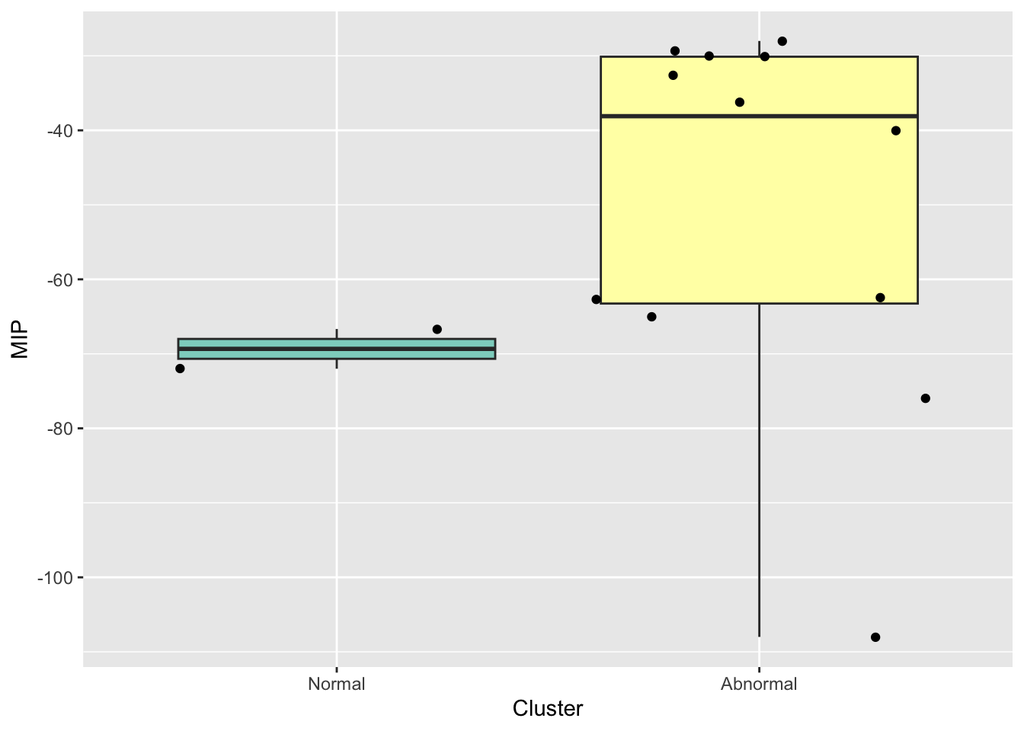

Figure 3: MIP Distribution Between Clusters (Subject-level)

```r
patient_cluster = k_means_df %>% dplyr::select(subject, visit, day, cluster_night) %>% group_by(subject) %>% summarize(cluster_patient = mean(cluster_night)) %>% ungroup()
patient_cluster$cluster_patient = sapply(patient_cluster$cluster_patient, function(x) case_when(x>=0.5~1,
                                                                                        .default = 0), USE.NAMES = FALSE)
patient_cluster =patient_cluster %>% left_join(k_means_df %>% dplyr::select(subject, visit, mip, fvc) %>% group_by(subject) %>% summarize(mip = mean(mip), fvc = mean(fvc)), by = c("subject")) %>% distinct()

ggplot(patient_cluster, aes(x = as.factor(cluster_patient), y = mip, fill = as.factor(cluster_patient))) +
  geom_boxplot() +
  geom_jitter() +
  scale_x_discrete(labels = c("Normal", "Abnormal")) +
  scale_fill_brewer(palette = "Set3") +
  labs(x = "Cluster", y = "MIP", fill = "Cluster") +
  theme(legend.position = "none")

k_means_df  = k_means_df %>% left_join(patient_cluster %>% dplyr::select(subject, cluster_patient), by = c("subject"))

s_test = t.test(patient_cluster$mip[which(patient_cluster$cluster_patient == 1)], patient_cluster$mip[which(patient_cluster$cluster_patient == 0)], alternative = "two.sided")
```

- The Welch Two Sample t-test resulted in a p-value of 0.03, suggesting that there is a significant difference between the two groups.

## 2.3 Cox Regression Model

No significant results found for our current sample size. We would suggest trying with a larger sample size.

```r
cox_result = cox_result %>% mutate(estimate = sprintf("%.3f", estimate),
                                   p.value = sprintf("%.3f", p.value))
colnames(cox_result) = c("variable", "HR", "CI", "p.value", "outcome")
kable(cox_result, align = "c") %>% kable_styling(bootstrap_options = "striped") %>% row_spec(which(as.numeric(cox_result$p.value) <= 0.05), bold = F, color = "black", background = "lightyellow") %>%
  kable_classic(html_font = "Cambria")
```

| variable | HR | CI | p.value | outcome |
| --- | --- | --- | --- | --- |
| PCO2_range | 1.097 | 1.00, 1.20 | 0.054 | mip_60 |
| sd_delta_pct | 1.207 | 0.97, 1.49 | 0.085 | mip_60 |
| delta_pco2_event | 4.625 | 0.81, 26.5 | 0.085 | mip_60 |
| mean_delta_pct | 1.029 | 0.99, 1.07 | 0.140 | mip_60 |
| delta_pco2_50_event | 3.885 | 0.62, 24.2 | 0.146 | mip_60 |
| sd_PCO2 | 1.497 | 0.86, 2.60 | 0.154 | mip_60 |
| event_45.10 | 1.240 | 0.91, 1.69 | 0.174 | mip_60 |
| mean_PCO2 | 0.865 | 0.67, 1.12 | 0.273 | fvc_50 |
| event_45 | 1.076 | 0.94, 1.23 | 0.273 | mip_60 |
| median_PCO2 | 0.866 | 0.67, 1.12 | 0.279 | fvc_50 |
| event_50 | 1.154 | 0.85, 1.57 | 0.364 | mip_60 |
| mean_PCO2 | 1.043 | 0.93, 1.17 | 0.478 | mip_60 |
| median_PCO2 | 1.043 | 0.93, 1.17 | 0.480 | mip_60 |
| event_50 | 0.388 | 0.02, 6.09 | 0.500 | fvc_50 |
| delta_pco2_50_event | 0.186 | 0.00, 36.4 | 0.532 | fvc_50 |
| mean_delta_pct | 1.017 | 0.95, 1.09 | 0.630 | fvc_50 |
| PCO2_range | 0.953 | 0.77, 1.18 | 0.654 | fvc_50 |
| delta_pco2_event | 1.853 | 0.10, 35.3 | 0.682 | fvc_50 |
| sd_PCO2 | 0.822 | 0.27, 2.46 | 0.726 | fvc_50 |
| event_45 | 0.958 | 0.70, 1.30 | 0.786 | fvc_50 |
| sd_delta_pct | 1.024 | 0.70, 1.51 | 0.903 | fvc_50 |
| event_45.10 | 0.991 | 0.55, 1.80 | 0.977 | fvc_50 |